# (Flights Data Exploration)

## by (Mohammed Alabdullatif)

## Investigation Overview

> I'm Intrested to know more about the flights delays and the cancelation and is the airport effect and the delay reason

## Dataset Overview

> This dataset reports flights in the United States, including carriers, arrival and departure delays, and reasons for delays, for 1988, 1998 and 2008

## (Number of Cancelled Flights 1)

> The chance of of get to cancelled your flight is 1.9% only, and it's important to be in low to keep the flight going and the airlines not losing

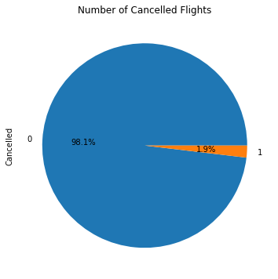

```python
plt.title('Number of Cancelled Flights') #add the title
# plot the digram in pie type, write the persintage on the pie and change it the size
flights['Cancelled'].value_counts().plot(kind="pie",autopct='%1.1f%%', figsize=[10,6]);
```

## (Top 10 Destination Airports 2)

> The Top Airports that have many flights lands on it.

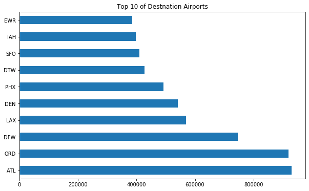

```python
plt.title('Top 10 of Destnation Airports') #add the title
top_10_Dep.plot(kind="barh", figsize=[10,6]); # plot the digram in bar type and change it the size
```

## (Carriers and airport with with Cancelled flights"Origin" 3)

> A lot of flights in LAX is cancelled

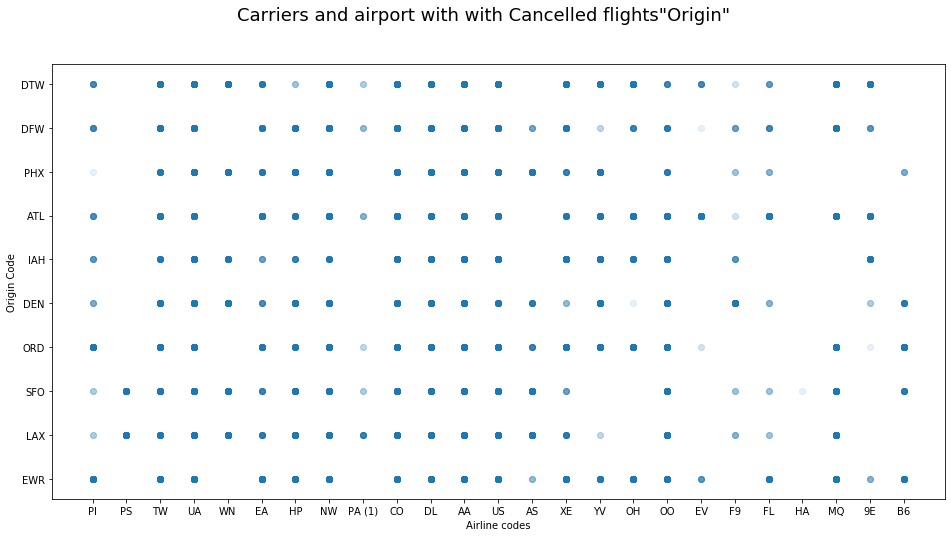

```python
# Set the plot size
fig = plt.figure(figsize = [16,8])

# use the scatter
plt.scatter(data = Flights_Top_Arr_Can, x = 'UniqueCarrier', y='Origin', alpha = .1)

# write the title
fig.suptitle('Carriers and airport with with Cancelled flights"Origin"', fontsize=18)

# write x and y labels
plt.xlabel('Airline codes')
plt.ylabel('Origin Code');
```

## (The Status of the Top Origin Airports 4)

> ORD and ATl have the most Delay Airports.

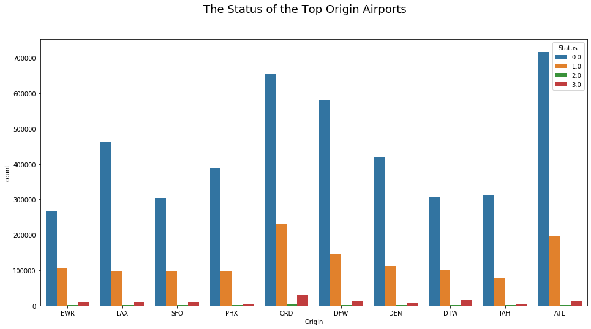

```python
# Set the plot size
fig = plt.figure(figsize = [16,8])

# write the title
fig.suptitle('The Status of the Top Origin Airports', fontsize=18)

# use the bar plot
sb.countplot(data = Flights_Top_Arr, x = 'Origin', hue = 'Status');
```

## (The Delay for the Carrier in the top Airlines ( Origin ) 5)

> ORD Airlines is the most delayed airlaines specially in UA, NW and CO and the delay take more time SFO is best Airlines with less time in the delay.

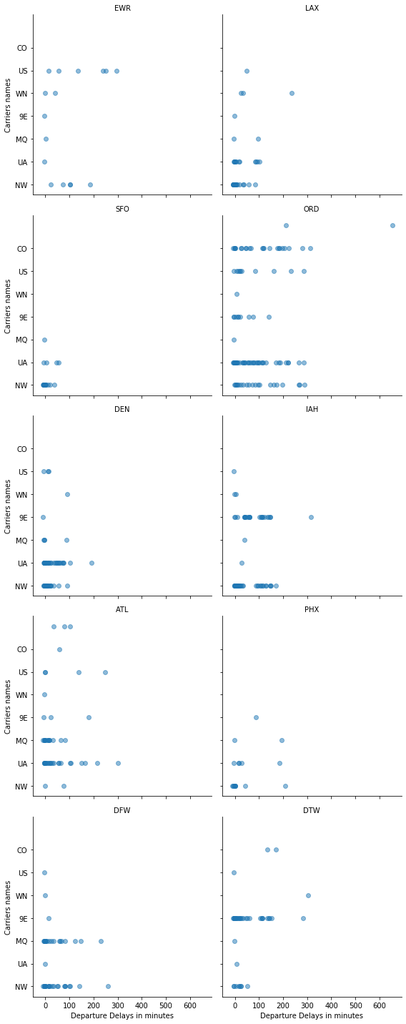

```python
# I use faceting by Origin
Flight_Cancel_plot = sb.FacetGrid(Flights_Top_Arr_Can, col = 'Origin', col_wrap = 2,palette="Set1", size = 4)

# Each graph is a categorical for departure delays and carrier name
Flight_Cancel_plot.map(plt.scatter, 'DepDelay', 'UniqueCarrier', alpha = .5 )

# set the axis labels
Flight_Cancel_plot.set_axis_labels("Departure Delays in minutes", "Carriers names");

# set each facet title with the Origin name
Flight_Cancel_plot.set_titles("{col_name}");
```

## (The canellation code for the Carrier in the top Airlines ( Origin ) 6)

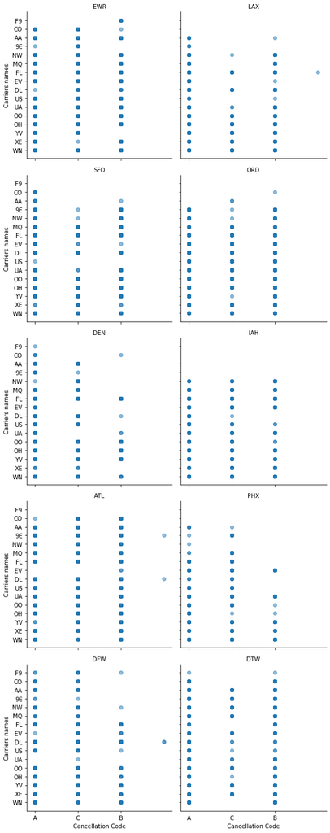

```python
# I use faceting by Origin
Flight_Cancel_plot = sb.FacetGrid(Flights_Top_Arr_Can, col = 'Origin', col_wrap = 2,palette="Set1", size = 4)

# Each graph is a categorical for departure delays and carrier name
Flight_Cancel_plot.map(plt.scatter, 'CancellationCode', 'UniqueCarrier', alpha = .5 )

# set the axis labels
Flight_Cancel_plot.set_axis_labels("Cancellation Code", "Carriers names");

# set each facet title with the Origin name
Flight_Cancel_plot.set_titles("{col_name}");
```